# Inferencia de una variable nominal (ambiente tectónico): modelo binomial

Unidad 2 · Estadística inferencial · Geoquímica de rocas con datos de EarthChem PetDB

Cristoffer Rumiguano, Ana Gabriela Fernández, Evelyn Bustamante, Jessica Haro, Jhonattan Ligña

Noviembre de 2026

> Proyecto estrictamente académico (Estadística y Probabilidades, FIGEMPA – UCE). Datos: EarthChem PetDB (CC BY 4.0), descargados el 13/10/2026. Web del proyecto: https://crisrumiguano-art.github.io/geoquimica-earthchem-ml/

## 1. Carga de datos

La inferencia se hace con la **muestra aleatoria simple** de la Lección 3: 1 061 porciones de roca sorteadas de las 159 760 de la base (semilla 2026). Con la base entera, el test de chi-cuadrado rechaza cualquier modelo por diferencias mínimas; con una muestra aleatoria mide lo que importa.

**Población, marco muestral y muestra.** La población (U) son todas las porciones de roca de la corteza y del manto superior de la Tierra: es infinita y nunca se conoce. El **marco muestral** es la base EarthChem PetDB (159 760 porciones de roca registradas): la lista de la que se sorteó la muestra. Por eso, en rigor, la inferencia vale para la población que representa la base, con su sesgo hacia las rocas oceánicas (Lección 3). Al final, la base completa sirve para **validar el método**: si el intervalo calculado con la muestra contiene el valor del marco, el procedimiento funcionó.

```r
knitr::opts_chunk$set(echo = TRUE, message = FALSE, warning = FALSE, fig.align = "center")
library(MASS)          # fitdistr(): estima los parámetros del modelo (viene con R)
dir.create("data/muestras", recursive = TRUE, showWarnings = FALSE)
if (!file.exists("data/muestras/muestra_aleatoria.csv")) {
  download.file("https://github.com/crisrumiguano-art/geoquimica-earthchem-ml/raw/main/data/muestras/muestra_aleatoria.csv", "data/muestras/muestra_aleatoria.csv", mode = "wb")
}
muestra <- read.csv("data/muestras/muestra_aleatoria.csv", check.names = FALSE)
dim(muestra)           # filas y columnas
```

```
## [1] 1061   76
```

## 2. Tabla de distribución de cantidad

Variable **nominal**: ambiente tectónico agrupado. Cada porción de roca es un ensayo con dos resultados: es de **margen convergente** (éxito) o no. La muestra se reparte, en el orden del sorteo, en lotes de 10 porciones de roca y se cuenta cuántas de margen convergente hay en cada lote: ese conteo (0 a 10) es la variable aleatoria X.

```r
x <- as.character(muestra[["Tectonic Group"]])
x <- x[!is.na(x) & x != ""]                            # quita vacíos (en el orden del sorteo)
exito <- x == "margen convergente"                            # TRUE = porciones de roca de margen convergente
c(casos = length(x), exitos = sum(exito), proporcion = mean(exito))
```

```
##        casos       exitos   proporcion
## 1060.0000000  218.0000000    0.2056604
```

```r
lote <- 10
B <- floor(length(exito) / lote)                      # número de lotes
grupo <- rep(1:B, each = lote)                         # a qué lote va cada análisis
y <- as.vector(tapply(exito[1:(B * lote)], grupo, sum))  # éxitos en cada lote
Fo <- as.vector(table(factor(y, levels = 0:max(y))))   # cuántas veces salió 0, 1, 2, ...
hi <- round(Fo / sum(Fo) * 100, 2)
TDF <- data.frame(valor = 0:max(y), ni = Fo, hi)
knitr::kable(TDF, caption = "Tabla N° 1: distribución de X = porciones de roca de margen convergente en un lote de 10")
```

Tabla N° 1: distribución de X = porciones de roca de margen convergente en un lote de 10

| valor | ni | hi |
| --- | --- | --- |
| 0 | 11 | 10.38 |
| 1 | 26 | 24.53 |
| 2 | 32 | 30.19 |
| 3 | 24 | 22.64 |
| 4 | 9 | 8.49 |
| 5 | 4 | 3.77 |

## 3. Gráfica de distribución de cantidad

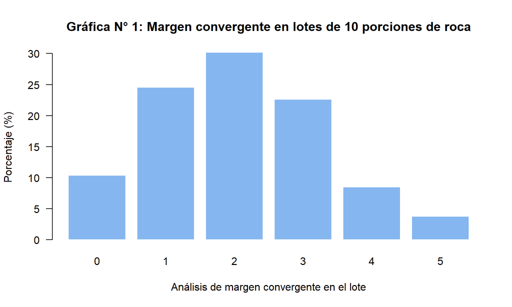

```r
barplot(hi, names.arg = 0:max(y), col = "#86b6ef", border = "white", las = 1,
        main = "Gráfica N° 1: Margen convergente en lotes de 10 porciones de roca", xlab = "Análisis de margen convergente en el lote", ylab = "Porcentaje (%)")
```

**Probabilidad clásica y ley de los grandes números.** Si se recorre la muestra en el orden del sorteo, la proporción de éxitos acumulada se estabiliza a medida que crece el número de casos: se acerca a la probabilidad del marco.

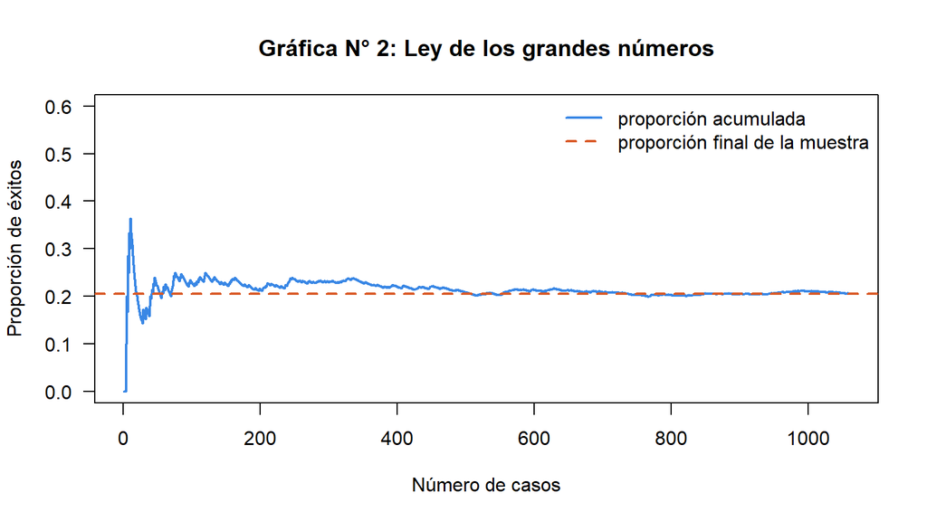

```r
frecuencia <- cumsum(exito) / seq_along(exito)         # proporción acumulada después de cada caso
plot(frecuencia, type = "l", col = "#3987e5", lwd = 2, las = 1, ylim = c(0, 0.6),
     main = "Gráfica N° 2: Ley de los grandes números", xlab = "Número de casos", ylab = "Proporción de éxitos")
abline(h = mean(exito), col = "#d95926", lwd = 2, lty = 2)
legend("topright", c("proporción acumulada", "proporción final de la muestra"), col = c("#3987e5", "#d95926"),
       lty = c(1, 2), lwd = 2, bty = "n")
```

## 4. Conjetura del modelo

X cuenta éxitos en un número fijo de ensayos independientes (n = 10) con la misma probabilidad p: es el **modelo binomial**. p se estima con la proporción de éxitos.

```r
n_ensayos <- lote
p <- mean(y) / n_ensayos                               # probabilidad de éxito estimada
p
```

```
## [1] 0.2056604
```

```r
valores <- 0:max(y)
P <- dbinom(valores, n_ensayos, p)                                        # probabilidad de cada valor según el modelo
P[length(P)] <- 1 - pbinom(max(y) - 1, n_ensayos, p)                                # el último valor acumula la cola ("o más")
Fe <- P * length(y)                                    # frecuencia esperada
# Para el chi-cuadrado cada clase debe esperar al menos 5 casos: los valores altos se juntan en una clase "o más"
corte <- max(which(Fe >= 5))
Fo2 <- c(Fo[1:(corte - 1)], sum(Fo[corte:length(Fo)]))
Fe2 <- c(Fe[1:(corte - 1)], sum(Fe[corte:length(Fe)]))
clase <- c(0:(corte - 2), paste0(corte - 1, " o más"))
knitr::kable(data.frame(clase, Fo = Fo2, Fe = round(Fe2, 2)), caption = "Tabla N° 2: frecuencias observadas y esperadas")
```

Tabla N° 2: frecuencias observadas y esperadas

| clase | Fo | Fe |
| --- | --- | --- |
| 0 | 11 | 10.60 |
| 1 | 26 | 27.45 |
| 2 | 32 | 31.98 |
| 3 | 24 | 22.08 |
| 4 o más | 13 | 13.89 |

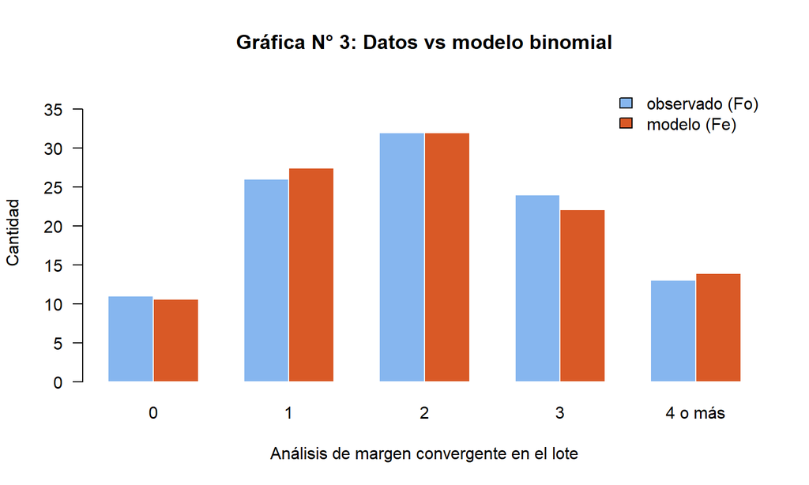

```r
barplot(rbind(Fo2, Fe2), beside = TRUE, names.arg = clase, col = c("#86b6ef", "#d95926"), border = "white", las = 1,
        ylim = c(0, max(Fo2, Fe2) * 1.2),
        main = "Gráfica N° 3: Datos vs modelo binomial", xlab = "Análisis de margen convergente en el lote", ylab = "Cantidad")
legend("topright", c("observado (Fo)", "modelo (Fe)"), fill = c("#86b6ef", "#d95926"), bty = "n")
```

## 5. Test de aprobación

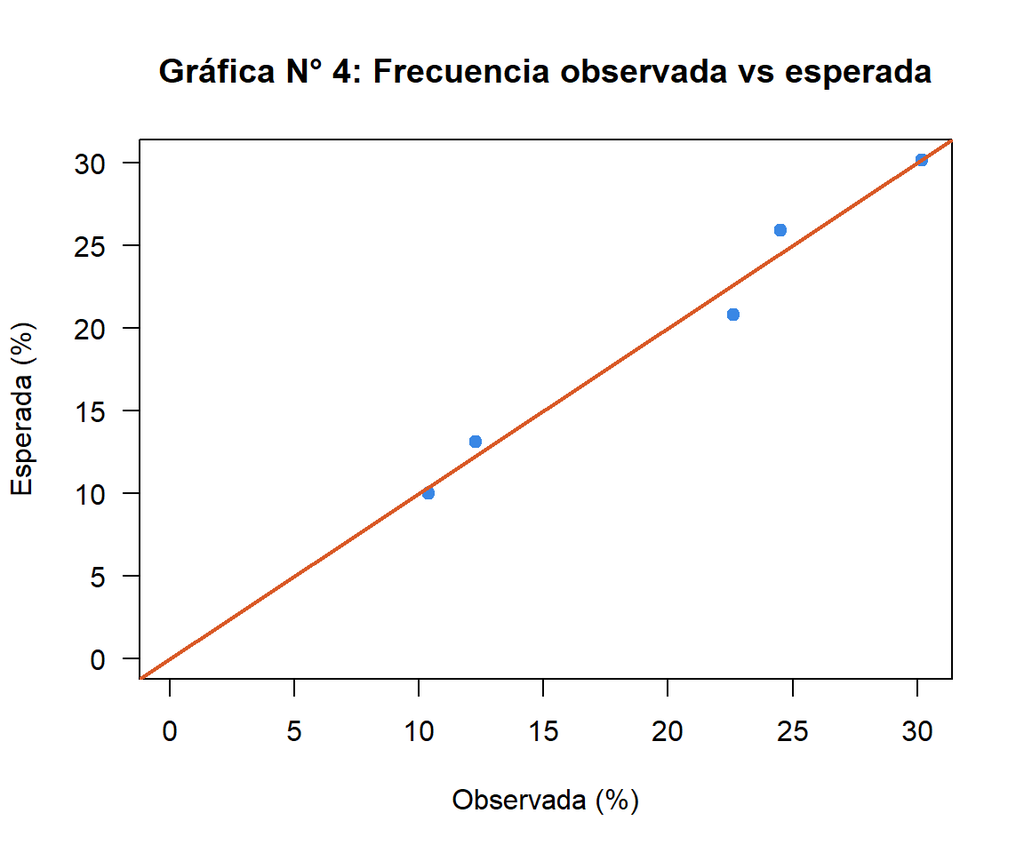

```r
lim <- range(0, Fo2 / sum(Fo2) * 100, Fe2 / sum(Fo2) * 100)   # mismos ejes en x e y
plot(Fo2 / sum(Fo2) * 100, Fe2 / sum(Fo2) * 100, pch = 19, col = "#3987e5", las = 1, xlim = lim, ylim = lim,
     main = "Gráfica N° 4: Frecuencia observada vs esperada", xlab = "Observada (%)", ylab = "Esperada (%)")
abline(a = 0, b = 1, col = "#d95926", lwd = 2)
```

```r
pearson <- cor(Fo2, Fe2) * 100
gl <- length(Fo2) - 1
x2 <- sum((Fo2 - Fe2)^2 / Fe2)
umbral <- qchisq(0.95, gl)
resultado <- ifelse(x2 < umbral, "se acepta el modelo", "se rechaza el modelo")
knitr::kable(data.frame(Variable = "X = porciones de roca de margen convergente en un lote de 10", Pearson = round(pearson, 2), Chi_cuadrado = round(x2, 2),
                        Umbral = round(umbral, 2), Resultado = resultado),
             caption = "Tabla N° 3: pruebas de bondad de ajuste")
```

Tabla N° 3: pruebas de bondad de ajuste

| Variable | Pearson | Chi_cuadrado | Umbral | Resultado |
| --- | --- | --- | --- | --- |
| X = porciones de roca de margen convergente en un lote de 10 | 98.95 | 0.32 | 9.49 | se acepta el modelo |

El chi-cuadrado (0.32) es menor que el umbral (9.49): se acepta el modelo. La correlación entre lo observado y lo esperado es de 98.9 %.

## 6. Estimación de probabilidades

**En un lote de 10 porciones de roca tomadas al azar, ¿cuál es la probabilidad de que haya 3 o más de margen convergente?**

```r
p1 <- 1 - pbinom(2, n_ensayos, p)
p1 * 100
```

```
## [1] 33.93493
```

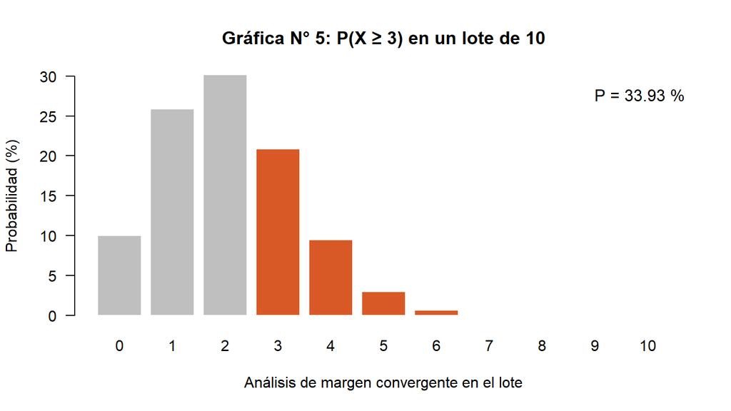

```r
vp <- 0:10                                       # valores posibles que se dibujan
Pp <- dbinom(vp, n_ensayos, p)
barplot(Pp * 100, names.arg = vp, las = 1, border = "white", col = ifelse(vp >= 3, "#d95926", "gray75"),
        main = "Gráfica N° 5: P(X ≥ 3) en un lote de 10", xlab = "Análisis de margen convergente en el lote", ylab = "Probabilidad (%)")
legend("topright", paste0("P = ", round(p1 * 100, 2), " %"), bty = "n", cex = 1.1)
```

**Si se revisan 50 lotes de 10, ¿en cuántos no habría ninguna porción de roca de margen convergente?**

```r
p0 <- dbinom(0, n_ensayos, p)
c(probabilidad = p0 * 100, lotes_esperados_de_50 = p0 * 50)
```

```
##          probabilidad lotes_esperados_de_50
##             10.001434              5.000717
```

## 7. Intervalos de confianza

Intervalo de confianza del 95 % para la **proporción poblacional** de porciones de roca de margen convergente, con la aproximación normal (n grande): p ± z·√(p(1 − p)/n).

```r
p_m <- mean(exito)                                     # proporción en la muestra
z <- qnorm(0.975)
E <- z * sqrt(p_m * (1 - p_m) / length(exito))         # error máximo de estimación
IC <- c(inferior = p_m - E, proporcion = p_m, superior = p_m + E)
round(IC * 100, 2)                                     # en %
```

```
##   inferior proporcion   superior
##      18.13      20.57      23.00
```

**Validación con el marco muestral.** La proporción en toda la base (el marco del que se sorteó la muestra) sí se puede calcular: ¿el intervalo de la muestra la contiene? Es una prueba del método, no la proporción de la población.

```r
if (!file.exists("data/earthchem_limpio.csv.gz")) {
  download.file("https://github.com/crisrumiguano-art/geoquimica-earthchem-ml/raw/main/data/earthchem_limpio.csv.gz", "data/earthchem_limpio.csv.gz", mode = "wb")
}
base <- read.csv(gzfile("data/earthchem_limpio.csv.gz", encoding = "UTF-8"), check.names = FALSE)
todos <- as.character(base[["Tectonic Group"]])
todos <- todos[!is.na(todos) & todos != ""]
p_marco <- mean(todos == "margen convergente")
c(proporcion_marco = p_marco, dentro_del_intervalo = p_marco >= IC[["inferior"]] & p_marco <= IC[["superior"]])
```

```
##     proporcion_marco dentro_del_intervalo
##            0.2124348            1.0000000
```

## 8. Conclusión

El número de porciones de roca de margen convergente en un lote de 10 sigue un **modelo binomial** con n = 10 y p = 0.206. El modelo pasa el test (chi-cuadrado 0.32 < umbral 9.49; Pearson 98.9 %). Con el 95 % de confianza, la proporción poblacional de porciones de roca de margen convergente está entre 18.13 % y 23 %, y la proporción del marco muestral (21.24 %, toda la base) cae dentro del intervalo.